# Project: Health Dataset Analysis and Prediction

## Course: Data Warehousing and Mining

### Name: Md Anwar Hossain

### Date: 14 June 2026

**Purpose of the assignment:** This assignment assesses the following Unit Learning Outcomes; students should be able to demonstrate their achievements in them.

1. Critically evaluate data quality to advocate application of data pre-processing techniques;
2. Devise implementation solutions that involve supervised learning including regression and classification on real-world data sets;
3. Experiment and evaluate unsupervised learning solutions including clustering and association rules mining on large datasets; and
4. Critically reflect on advantages and disadvantages of particular data mining solutions to solve real life problems and evaluate their usefulness and useability.

**ASSIGNMENT DESCRIPTION** The objective of this assignment is to conduct a comprehensive machine learning analysis of a healthrelated dataset to explore various factors associated with health conditions, risk factors, patient outcomes, or disease prevalence, and to develop predictive models for healthcare-related decision making. Students will apply machine learning techniques to analyze the dataset, develop predictive models, and present their findings in a clear and concise manner, including model performance metrics and feature importance analyses.

Students will apply machine learning techniques to:

• Investigate demographic, clinical, behavioural, and lifestyle variables associated with the selected health condition or healthcare outcome

• Build and evaluate predictive models for healthcare-related prediction or classification tasks

• Present results clearly, including model performance metrics (e.g., accuracy, precision, recall, F1-score, ROC-AUC) and feature importance analyses

**Task 1 Dataset Selection**

You will select a health-related dataset for analysis. The chosen dataset should ideally (but not necessarily) include variables such as:

• Demographics: age, gender, ethnicity

• Clinical measurements: blood pressure, cholesterol levels, BMI, glucose levels, heart rate, or other relevant medical indicators

• Diagnostic or medical test results: laboratory findings, ECG results, imaging results, or disease-specific test outcomes

• Lifestyle factors: smoking status, physical activity level, diet, alcohol consumption, sleep patterns, etc.

• Health outcomes: disease presence/severity, diagnosis status, recovery outcomes, hospital readmission, or other health-related target variables Example health-related datasets include heart disease, diabetes, breast cancer, stroke prediction, chronic kidney disease, COVID-19, mental health, obesity, sleep health, and hospital readmission datasets.

**Potential sources:**

• UCI Machine Learning Repository

• Kaggle

• Public health agencies and government open-data portals

• WHO, CDC, or other healthcare-related repositories

Before proceeding to analysis, show your chosen dataset to the lecturer and obtain confirmation to ensure data quality, completeness, and suitability for your machine learning project.

**Task 2 Research Questions**

Research questions are essential for guiding the machine learning analysis and exploration of the selected health-related dataset. By considering the dataset’s variables and healthcare context, students can uncover insights into disease prevalence, risk factors, patient outcomes, healthcare trends, and treatment effectiveness. These questions will provide a framework for investigating relationships and associations within the dataset, enhancing understanding and supporting evidence-based healthcare decisions and policies.

**To build a strong foundation, you should:**

1. Conduct a Literature Survey: Review existing research and literature related to the selected health condition, healthcare problem, or predictive modeling techniques to better understand current knowledge, trends, and research gaps. The literature survey must include a summary of at least three recent research papers from reputable journals or conferences.
2. Formulate Research Questions: Develop specific research questions based on the dataset’s variables and healthcare context. Example questions might include:

• What are the significant factors associated with the selected health condition or outcome?

• Is there a relationship between demographic factors (e.g., age or gender) and the target health outcome?

• How do lifestyle factors, such as diet, exercise, smoking, or sleep, influence health outcomes?

• Which variables contribute most significantly to prediction accuracy in the machine learning model?

• Can machine learning models effectively predict disease risk, hospital readmission, or patient outcomes?

• This task will combine insights from the literature with dataset analysis, supporting a well-rounded approach to answering critical healthcare-related research questions.

**Task 3 Data Exploration**

The objective of this data exploration task is to understand and summarize the characteristics of the dataset collected in Task 1. Once the relevant data has been collected, the following tasks need to be performed:

• Load and Examine the Dataset: Load the selected dataset and examine its structure, including variable types and any missing data patterns.

• Explore Variable Distributions: Use summary statistics and visualizations to explore the distribution of each variable, identifying any irregularities, trends, or patterns.

• Perform Descriptive Analysis: Conduct descriptive analyses to provide an overview of the data's characteristics, including variable ranges, counts, and key relationships.

• Calculate Central Tendency and Dispersion: Compute key measures of central tendency (e.g., mean, median) and dispersion (e.g., variance, standard deviation) to gain insights into the dataset's features, detect potential outliers, and inform the data pre-processing and modeling steps.

This exploration will provide a foundational understanding of the dataset's structure and variability, supporting informed decisions in the modeling process.

**Task 4 Data Visualization**

Graphical representations play a crucial role in exploratory data analysis, allowing students to visually inspect the dataset, identify patterns and relationships, and generate hypotheses for further investigation. You need to create graphical representations (histograms, box plots, line graphs) to visually depict the distribution of variables and identify any patterns, trends, or outliers. In addition, explore the relationships between variables through scatter plots or correlation matrices to understand potential associations.

**Task 5 Machine Learning Models and Performance Evaluation**

In this task, students will apply machine learning models to the dataset to develop predictive insights. This process includes selecting, training, and evaluating various models to assess their predictive performance and identify the best model for the disease prediction.

The steps involved in this task are as follows:

a) Model Selection: Select any 3 appropriate machine learning models to test on the dataset.

**Suggested models may include:**

• **Logistic Regression:** A simple, interpretable model suitable for binary classification problems.

• **Decision Trees and Random Forests:** Models that capture complex patterns, useful for handling non-linear relationships.

• **Support Vector Machines (SVM):** Effective for high-dimensional spaces, useful if the dataset has multiple features. • **Neural Networks:** A more complex model option, particularly useful if the dataset is large and has non-linear patterns. Justify the choice of models based on the dataset characteristics and desired interpretability versus accuracy trade-offs.

b) Data Splitting:

Divide the dataset into training and test sets (e.g., 80-20 split). Consider using cross-validation to ensure model robustness and avoid overfitting. This involves training the model on multiple subsets of the data and averaging the results to obtain more reliable performance estimates.

c) Model Training and Hyperparameter Tuning: Train each selected model on the training set. For better performance, optimize each model's hyperparameters using techniques like grid search or randomized search cross-validation.

d) Performance Evaluation Metrics:

Evaluate each model's performance on the test set using the following metrics:

• Accuracy: The percentage of correctly classified instances, which provides a basic performance indicator.

• Precision and Recall: Metrics that provide insights into the model’s ability to accurately predict positive cases (Precision) and identify actual positive cases (Recall).

• F1 Score: A balanced measure that considers both precision and recall, useful for evaluating models on imbalanced data.

Use confusion matrices to visualize each model’s performance and to understand the types of errors it makes.

e) Model Comparison and Selection:

Compare the performance of all models based on the evaluation metrics to determine the most suitable model for predicting health condition Consider both accuracy and interpretability; a simpler model might be preferred if it achieves comparable results to a complex model.

**Task 6 Interpretation, Conclusion and References**

In this final task, students will summarize key findings and interpret the results in relation to the research questions.

• Summarize Findings: Provide a clear summary of the main findings from the machine learning analysis, linking them back to the original research questions. Highlight important insights regarding risk factors, predictors, and any associations identified in the dataset.

• Discuss Implications: Discuss the implications of these findings for understanding the disease risk factors and potential prevention strategies, noting how these insights may inform health interventions or policies.

• Identify Limitations: Acknowledge any limitations in the analysis, such as data quality, sample size, or model constraints. This section should provide a critical evaluation of potential biases or data limitations that may have impacted the findings.

• Future Research Directions: Suggest directions for future research that could build on this analysis, such as testing additional variables, exploring other predictive models, or applying the analysis to different populations.

• References and Citations: Include relevant references and citations from the literature, ensuring that all sources used throughout the project are properly credited.

# **A. Exploratory Data Analysis and pre-processing**

## **1. Load dataset and Initial Inspection**

```python
import pandas as pd
import numpy as np

df = pd.read_csv("E:/NIT6160 - Data Warehousing and Mining/Project - Data Warehousing and Mining/cardio_train.csv")

# Basic info
print(df.shape)
print(df.head())
```

```
(70000, 12)
     age  gender  height  weight  ap_hi  ap_lo  cholesterol  gluc  smoke  \
0  18393       2     168    62.0    110     80            1     1      0
1  20228       1     156    85.0    140     90            3     1      0
2  18857       1     165    64.0    130     70            3     1      0
3  17623       2     169    82.0    150    100            1     1      0
4  17474       1     156    56.0    100     60            1     1      0

   alco  active  cardio
0     0       1       0
1     0       1       1
2     0       0       1
3     0       1       1
4     0       0       0
```

Features information (provided by source of the dataset):

```
Age | Objective Feature | age | int (days)
Height | Objective Feature | height | int (cm) |
Weight | Objective Feature | weight | float (kg) |
Gender | Objective Feature | gender | categorical code |
Systolic blood pressure | Examination Feature | ap_hi | int |
Diastolic blood pressure | Examination Feature | ap_lo | int |
Cholesterol | Examination Feature | cholesterol | 1: normal, 2: above normal, 3: well above normal |
Glucose | Examination Feature | gluc | 1: normal, 2: above normal, 3: well above normal |
Smoking | Subjective Feature | smoke | binary |
Alcohol intake | Subjective Feature | alco | binary |
Physical activity | Subjective Feature | active | binary |
Presence or absence of cardiovascular disease | Target Variable | cardio | binary |
```

```python
# Data types and missing values
df.info()
```

```
<class 'pandas.DataFrame'>
RangeIndex: 70000 entries, 0 to 69999
Data columns (total 12 columns):
 #   Column       Non-Null Count  Dtype
---  ------       --------------  -----
 0   age          70000 non-null  int64
 1   gender       70000 non-null  int64
 2   height       70000 non-null  int64
 3   weight       70000 non-null  float64
 4   ap_hi        70000 non-null  int64
 5   ap_lo        70000 non-null  int64
 6   cholesterol  70000 non-null  int64
 7   gluc         70000 non-null  int64
 8   smoke        70000 non-null  int64
 9   alco         70000 non-null  int64
 10  active       70000 non-null  int64
 11  cardio       70000 non-null  int64
dtypes: float64(1), int64(11)
memory usage: 6.4 MB
```

```python
# Summary statistics
df.describe()
```

|  | age | gender | height | weight | ap_hi | ap_lo | cholesterol | gluc | smoke | alco | active | cardio |
| --- | --- | --- | --- | --- | --- | --- | --- | --- | --- | --- | --- | --- |
| count | 70000.000000 | 70000.000000 | 70000.000000 | 70000.000000 | 70000.000000 | 70000.000000 | 70000.000000 | 70000.000000 | 70000.000000 | 70000.000000 | 70000.000000 | 70000.000000 |
| mean | 19468.865814 | 1.349571 | 164.359229 | 74.205690 | 128.817286 | 96.630414 | 1.366871 | 1.226457 | 0.088129 | 0.053771 | 0.803729 | 0.499700 |
| std | 2467.251667 | 0.476838 | 8.210126 | 14.395757 | 154.011419 | 188.472530 | 0.680250 | 0.572270 | 0.283484 | 0.225568 | 0.397179 | 0.500003 |
| min | 10798.000000 | 1.000000 | 55.000000 | 10.000000 | -150.000000 | -70.000000 | 1.000000 | 1.000000 | 0.000000 | 0.000000 | 0.000000 | 0.000000 |
| 25% | 17664.000000 | 1.000000 | 159.000000 | 65.000000 | 120.000000 | 80.000000 | 1.000000 | 1.000000 | 0.000000 | 0.000000 | 1.000000 | 0.000000 |
| 50% | 19703.000000 | 1.000000 | 165.000000 | 72.000000 | 120.000000 | 80.000000 | 1.000000 | 1.000000 | 0.000000 | 0.000000 | 1.000000 | 0.000000 |
| 75% | 21327.000000 | 2.000000 | 170.000000 | 82.000000 | 140.000000 | 90.000000 | 2.000000 | 1.000000 | 0.000000 | 0.000000 | 1.000000 | 1.000000 |
| max | 23713.000000 | 2.000000 | 250.000000 | 200.000000 | 16020.000000 | 11000.000000 | 3.000000 | 3.000000 | 1.000000 | 1.000000 | 1.000000 | 1.000000 |

## **2. Fix Age (Days → Years)**

- Age is stored in days
- Interpretation (plots, coefficients, reporting) is much clearer in years
- Models are unaffected numerically, but interpretability improves significantly

```python
df["age_years"] = df["age"] / 365

# round to one decimal place for readability
df["age_years"] = df["age_years"].round(1)

# Drop original age (avoid redundancy)
df.drop(columns=["age"], inplace=True)
# inplace=True, tells Pandas to modify the existing DataFrame directly.
```

```python
# see dataframe again
df.head()
```

|  | gender | height | weight | ap_hi | ap_lo | cholesterol | gluc | smoke | alco | active | cardio | age_years |
| --- | --- | --- | --- | --- | --- | --- | --- | --- | --- | --- | --- | --- |
| 0 | 2 | 168 | 62.0 | 110 | 80 | 1 | 1 | 0 | 0 | 1 | 0 | 50.4 |
| 1 | 1 | 156 | 85.0 | 140 | 90 | 3 | 1 | 0 | 0 | 1 | 1 | 55.4 |
| 2 | 1 | 165 | 64.0 | 130 | 70 | 3 | 1 | 0 | 0 | 0 | 1 | 51.7 |
| 3 | 2 | 169 | 82.0 | 150 | 100 | 1 | 1 | 0 | 0 | 1 | 1 | 48.3 |
| 4 | 1 | 156 | 56.0 | 100 | 60 | 1 | 1 | 0 | 0 | 0 | 0 | 47.9 |

## **3. Check missing values**

```python
# check for missing values (already knew no missing values from 'df.info()' operation)
df.isnull().sum()
```

```
gender         0
height         0
weight         0
ap_hi          0
ap_lo          0
cholesterol    0
gluc           0
smoke          0
alco           0
active         0
cardio         0
age_years      0
dtype: int64
```

## **4. Create Additional Useful Feature (BMI)**

- BMI is a key cardiovascular risk factor
- Literature strongly supports its inclusion
- Ref. H. E. Bays, P. R. Taub, E. Epstein, E. D. Michos, R. A. Ferraro, A. L. Bailey, H. M. Kelli, K. C. Ferdinand, M. R. Echols, and H. Weintraub, “Ten things to know about ten cardiovascular disease risk factors,” American journal of preventive cardiology, vol. 5, pp. 100149, 2021.

BMI = weight(kg) / height(m)**2

```python
df["BMI"] = df["weight"] / ((df["height"] / 100) ** 2)
```

## **5. Check for outliers**

```python
# check summary statistics
df.describe()
```

|  | gender | height | weight | ap_hi | ap_lo | cholesterol | gluc | smoke | alco | active | cardio | age_years | BMI |
| --- | --- | --- | --- | --- | --- | --- | --- | --- | --- | --- | --- | --- | --- |
| count | 70000.000000 | 70000.000000 | 70000.000000 | 70000.000000 | 70000.000000 | 70000.000000 | 70000.000000 | 70000.000000 | 70000.000000 | 70000.000000 | 70000.000000 | 70000.000000 | 70000.000000 |
| mean | 1.349571 | 164.359229 | 74.205690 | 128.817286 | 96.630414 | 1.366871 | 1.226457 | 0.088129 | 0.053771 | 0.803729 | 0.499700 | 53.339486 | 27.556513 |
| std | 0.476838 | 8.210126 | 14.395757 | 154.011419 | 188.472530 | 0.680250 | 0.572270 | 0.283484 | 0.225568 | 0.397179 | 0.500003 | 6.759534 | 6.091511 |
| min | 1.000000 | 55.000000 | 10.000000 | -150.000000 | -70.000000 | 1.000000 | 1.000000 | 0.000000 | 0.000000 | 0.000000 | 0.000000 | 29.600000 | 3.471784 |
| 25% | 1.000000 | 159.000000 | 65.000000 | 120.000000 | 80.000000 | 1.000000 | 1.000000 | 0.000000 | 0.000000 | 1.000000 | 0.000000 | 48.400000 | 23.875115 |
| 50% | 1.000000 | 165.000000 | 72.000000 | 120.000000 | 80.000000 | 1.000000 | 1.000000 | 0.000000 | 0.000000 | 1.000000 | 0.000000 | 54.000000 | 26.374068 |
| 75% | 2.000000 | 170.000000 | 82.000000 | 140.000000 | 90.000000 | 2.000000 | 1.000000 | 0.000000 | 0.000000 | 1.000000 | 1.000000 | 58.400000 | 30.222222 |
| max | 2.000000 | 250.000000 | 200.000000 | 16020.000000 | 11000.000000 | 3.000000 | 3.000000 | 1.000000 | 1.000000 | 1.000000 | 1.000000 | 65.000000 | 298.666667 |

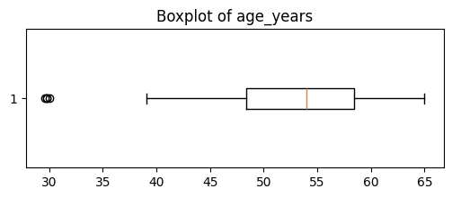

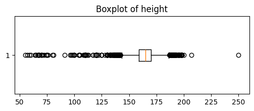

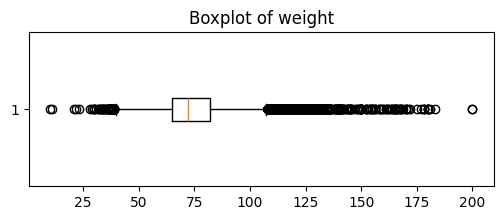

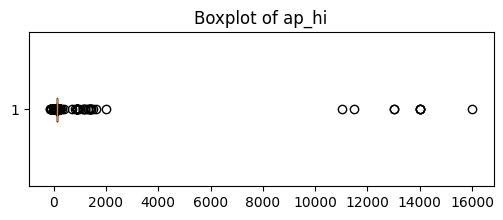

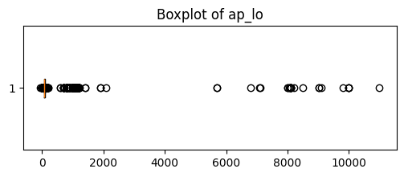

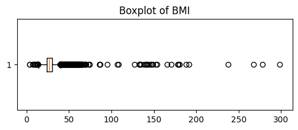

```python
import matplotlib.pyplot as plt

# Select only continuous columsn (not categorical ones)
numeric_cols = ['age_years', 'height', 'weight', 'ap_hi', 'ap_lo', 'BMI']

for col in numeric_cols:
    plt.figure(figsize=(6, 2))
    plt.boxplot(df[col].dropna(), vert=False)
    plt.title(f'Boxplot of {col}')
    plt.show()
```

```python
# use interquantile range for age, height, and weight to remove outliers
# remove rows outside 1.5 × IQR
# Columns to apply IQR
basic_cont_cols = ["age_years", "height", "weight"]

df_clean = df.copy()

for col in basic_cont_cols:
    Q1 = df_clean[col].quantile(0.25)
    Q3 = df_clean[col].quantile(0.75)
    IQR = Q3 - Q1

    lower_bound = Q1 - 1.5 * IQR
    upper_bound = Q3 + 1.5 * IQR

    df_clean = df_clean[
        (df_clean[col] >= lower_bound) &
        (df_clean[col] <= upper_bound)
    ]
```

```python
# remove outliers by human physiological limits for ap_hi, ap_lo, and BMI
df_clean = df_clean[(df_clean["ap_hi"] < 250) & (df_clean["ap_hi"] > 80)] # this conforms normal condition and without exercising
df_clean = df_clean[(df_clean["ap_lo"] < 150) & (df_clean["ap_lo"] > 50)] # this conforms normal condition and without exercising
df_clean = df_clean[(df_clean["BMI"] < 60) & (df_clean["BMI"] > 15)]

print("Shape after removing outliers:", df_clean.shape)
```

```
Shape after removing outliers: (66364, 13)
```

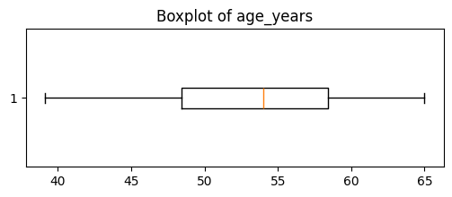

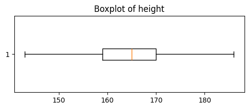

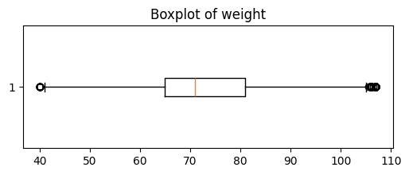

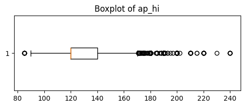

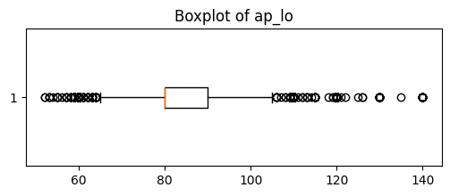

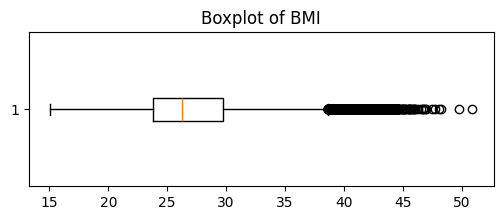

```python
# now see boxplot again
# Select only continuous columsn (not categorical ones)
numeric_cols = ['age_years', 'height', 'weight', 'ap_hi', 'ap_lo', 'BMI']

for col in numeric_cols:
    plt.figure(figsize=(6, 2))
    plt.boxplot(df_clean[col].dropna(), vert=False)
    plt.title(f'Boxplot of {col}')
    plt.show()
```

```python
# now see the summary of the df_clean dataset
df_clean.describe()
```

|  | gender | height | weight | ap_hi | ap_lo | cholesterol | gluc | smoke | alco | active | cardio | age_years | BMI |
| --- | --- | --- | --- | --- | --- | --- | --- | --- | --- | --- | --- | --- | --- |
| count | 66364.000000 | 66364.000000 | 66364.000000 | 66364.000000 | 66364.000000 | 66364.00000 | 66364.000000 | 66364.000000 | 66364.000000 | 66364.000000 | 66364.000000 | 66364.000000 | 66364.000000 |
| mean | 1.345624 | 164.317928 | 73.019088 | 126.424462 | 81.233485 | 1.35795 | 1.220451 | 0.086658 | 0.052498 | 0.804322 | 0.490281 | 53.332756 | 27.086600 |
| std | 0.475575 | 7.551844 | 12.368870 | 16.426176 | 9.309875 | 0.67383 | 0.566413 | 0.281336 | 0.223031 | 0.396725 | 0.499909 | 6.759188 | 4.593452 |
| min | 1.000000 | 143.000000 | 40.000000 | 85.000000 | 52.000000 | 1.00000 | 1.000000 | 0.000000 | 0.000000 | 0.000000 | 0.000000 | 39.100000 | 15.035584 |
| 25% | 1.000000 | 159.000000 | 65.000000 | 120.000000 | 80.000000 | 1.00000 | 1.000000 | 0.000000 | 0.000000 | 1.000000 | 0.000000 | 48.400000 | 23.833005 |
| 50% | 1.000000 | 165.000000 | 71.000000 | 120.000000 | 80.000000 | 1.00000 | 1.000000 | 0.000000 | 0.000000 | 1.000000 | 0.000000 | 54.000000 | 26.218821 |
| 75% | 2.000000 | 170.000000 | 81.000000 | 140.000000 | 90.000000 | 1.00000 | 1.000000 | 0.000000 | 0.000000 | 1.000000 | 1.000000 | 58.400000 | 29.757785 |
| max | 2.000000 | 186.000000 | 107.000000 | 240.000000 | 140.000000 | 3.00000 | 3.000000 | 1.000000 | 1.000000 | 1.000000 | 1.000000 | 65.000000 | 50.891795 |

```python
print(df.shape)
print(df_clean.shape)
```

```
(70000, 13)
(66364, 13)
```

## **6. Distribution Plots**

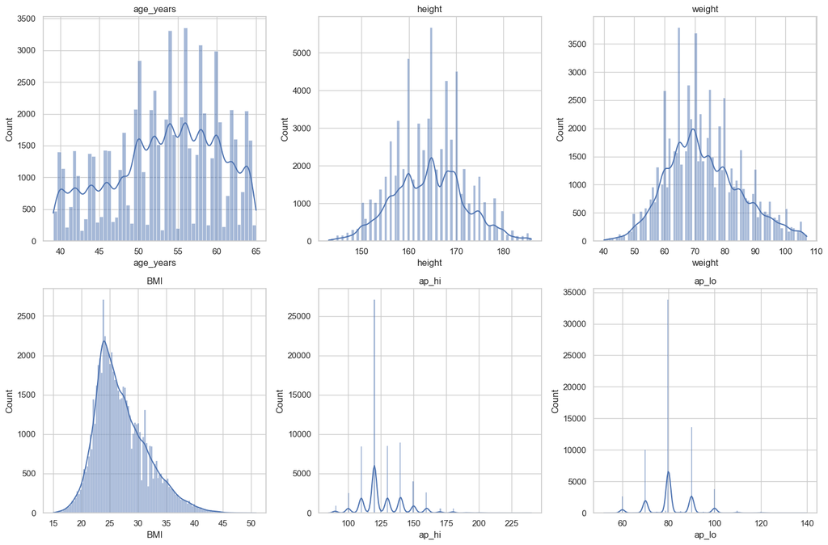

```python
import matplotlib.pyplot as plt
import seaborn as sns

sns.set(style="whitegrid")

# Continuous variables
cont_cols = ["age_years", "height", "weight", "BMI", "ap_hi", "ap_lo"]

plt.figure(figsize=(15, 10))
for i, col in enumerate(cont_cols, 1): # one plot per variable from the cont_cols
    plt.subplot(2, 3, i)
    sns.histplot(df_clean[col], kde=True)
    plt.title(col)

plt.tight_layout()
plt.show()
```

## **7. Distribution of Target 'Cardio' Column**

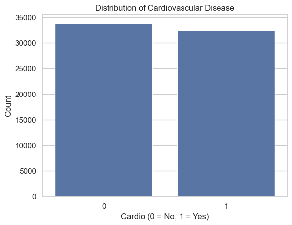

```python
sns.countplot(x="cardio", data=df_clean)
plt.title("Distribution of Cardiovascular Disease")
plt.xlabel("Cardio (0 = No, 1 = Yes)")
plt.ylabel("Count")
plt.show()
```

## **8. Compare Features by Target**

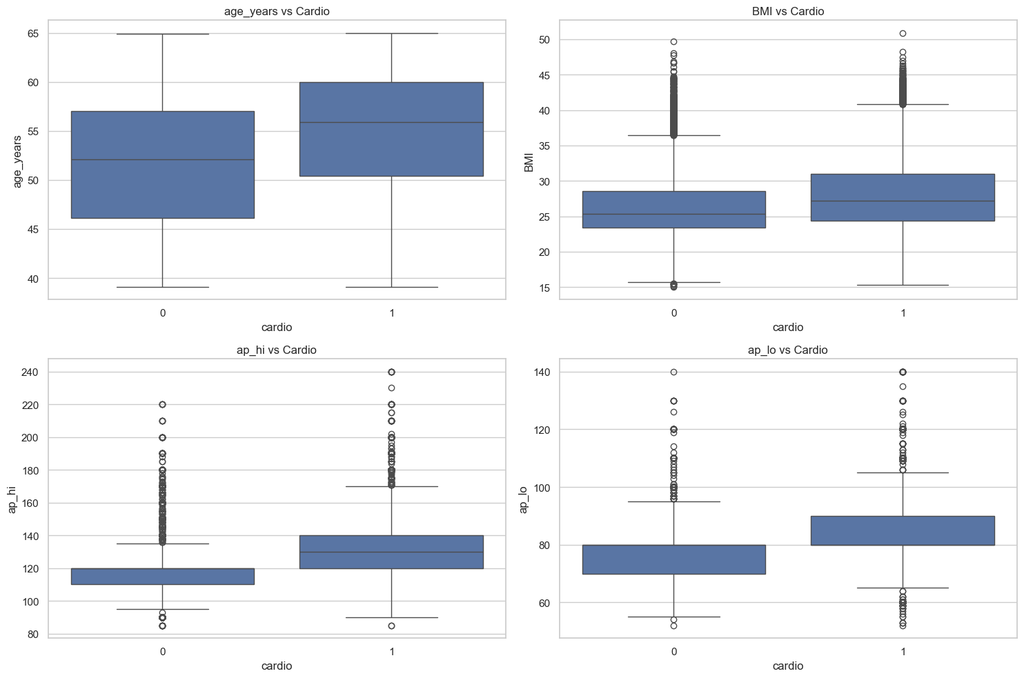

```python
plt.figure(figsize=(15, 10))

for i, col in enumerate(["age_years", "BMI", "ap_hi", "ap_lo"], 1):
    plt.subplot(2, 2, i)
    sns.boxplot(x="cardio", y=col, data=df_clean)
    plt.title(f"{col} vs Cardio")

plt.tight_layout()
plt.show()
```

## **9. Categorical Variables vs Target**

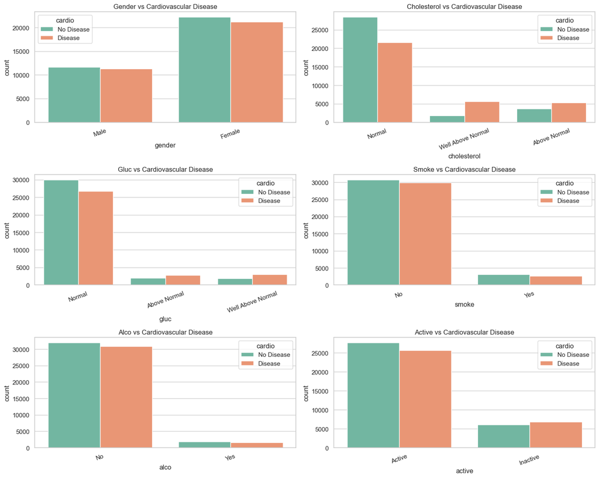

```python
import matplotlib.pyplot as plt
import seaborn as sns

# Create a copy for plotting
df_plot = df_clean.copy()

# ✅ Map categorical values to meaningful labels
df_plot["gender"] = df_plot["gender"].map({1: "Female", 2: "Male"})

df_plot["cholesterol"] = df_plot["cholesterol"].map({
    1: "Normal",
    2: "Above Normal",
    3: "Well Above Normal"
})

df_plot["gluc"] = df_plot["gluc"].map({
    1: "Normal",
    2: "Above Normal",
    3: "Well Above Normal"
})

# Optional (recommended for clarity)
df_plot["smoke"] = df_plot["smoke"].map({0: "No", 1: "Yes"})
df_plot["alco"] = df_plot["alco"].map({0: "No", 1: "Yes"})
df_plot["active"] = df_plot["active"].map({0: "Inactive", 1: "Active"})

df_plot["cardio"] = df_plot["cardio"].map({0: "No Disease", 1: "Disease"})


# ✅ Plot
cat_cols = ["gender", "cholesterol", "gluc", "smoke", "alco", "active"]

plt.figure(figsize=(15, 12))

for i, col in enumerate(cat_cols, 1):
    plt.subplot(3, 2, i)
    sns.countplot(x=col, hue="cardio", data=df_plot, palette = "Set2")
    plt.title(f"{col.capitalize()} vs Cardiovascular Disease")
    plt.xticks(rotation=20)

plt.tight_layout()
plt.show()
```

Categorical variables were relabelled with descriptive categories (e.g., gender: male/female; cholesterol: normal, above normal, well above normal) to enhance interpretability of visualisations.

## **10. Correlation Matrix**

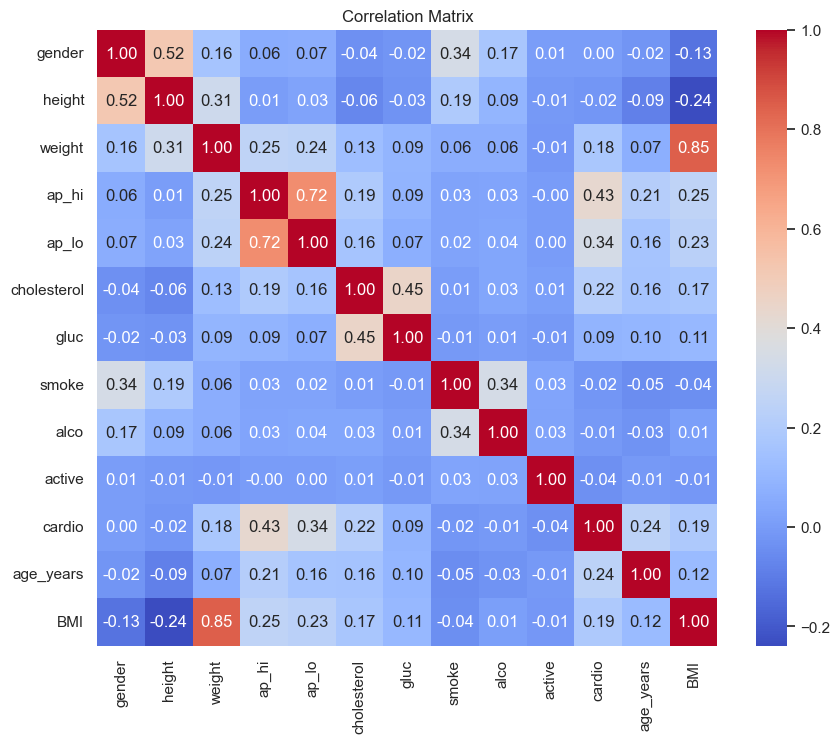

```python
plt.figure(figsize=(10, 8))
corr = df_clean.corr()

sns.heatmap(corr, annot=True, cmap="coolwarm", fmt=".2f")
plt.title("Correlation Matrix")
plt.show()
```

# **B. Logistic Regression**

## **1. Prepare Data**

```python
import pandas as pd
import numpy as np

# Features (X) and target (y)
X = df_clean.drop(columns=["cardio"])
y = df_clean["cardio"]
```

## **2. Handle Multicollinearity**

- BMI vs weight (0.85): Keep BMI, drop weight
- ap_hi vs ap_lo (0.72): Keep both (they represent systolic vs diastolic which are medically meaningful)

```python
# Drop highly correlated variable
X = X.drop(columns=["weight"])
```

## **3. Train/Test Split**

```python
from sklearn.model_selection import train_test_split

X_train, X_test, y_train, y_test = train_test_split(
    X, y, test_size=0.2, random_state=42, stratify=y
)

# stratify=y, preserves the same class proportions in both sets
# random_state = 42, is for reproducibility
```

## **4. Scaling of predictors to make sure they are on a same scale**

```python
from sklearn.preprocessing import StandardScaler

scaler = StandardScaler()

X_train_scaled = scaler.fit_transform(X_train)
X_test_scaled = scaler.transform(X_test)
```

## **5. Add Interaction + Quadratic Terms**

Use **PolynomialFeatures** to generate:

- interaction terms
- squared terms

```python
from sklearn.preprocessing import PolynomialFeatures

# degree=2 includes:
# - linear terms
# - interaction terms
# - quadratic terms
poly = PolynomialFeatures(degree=2, interaction_only=False, include_bias=False)

X_train_poly = poly.fit_transform(X_train_scaled)
X_test_poly = poly.transform(X_test_scaled)

# Get feature names (VERY IMPORTANT for interpretation)
feature_names = poly.get_feature_names_out(X.columns)

print("Total features after expansion:", len(feature_names))
```

```
Total features after expansion: 77
```

```python
# see how the quadratic and interaction terms used
print(feature_names)
```

```
['gender' 'height' 'ap_hi' 'ap_lo' 'cholesterol' 'gluc' 'smoke' 'alco'
 'active' 'age_years' 'BMI' 'gender^2' 'gender height' 'gender ap_hi'
 'gender ap_lo' 'gender cholesterol' 'gender gluc' 'gender smoke'
 'gender alco' 'gender active' 'gender age_years' 'gender BMI' 'height^2'
 'height ap_hi' 'height ap_lo' 'height cholesterol' 'height gluc'
 'height smoke' 'height alco' 'height active' 'height age_years'
 'height BMI' 'ap_hi^2' 'ap_hi ap_lo' 'ap_hi cholesterol' 'ap_hi gluc'
 'ap_hi smoke' 'ap_hi alco' 'ap_hi active' 'ap_hi age_years' 'ap_hi BMI'
 'ap_lo^2' 'ap_lo cholesterol' 'ap_lo gluc' 'ap_lo smoke' 'ap_lo alco'
 'ap_lo active' 'ap_lo age_years' 'ap_lo BMI' 'cholesterol^2'
 'cholesterol gluc' 'cholesterol smoke' 'cholesterol alco'
 'cholesterol active' 'cholesterol age_years' 'cholesterol BMI' 'gluc^2'
 'gluc smoke' 'gluc alco' 'gluc active' 'gluc age_years' 'gluc BMI'
 'smoke^2' 'smoke alco' 'smoke active' 'smoke age_years' 'smoke BMI'
 'alco^2' 'alco active' 'alco age_years' 'alco BMI' 'active^2'
 'active age_years' 'active BMI' 'age_years^2' 'age_years BMI' 'BMI^2']
```

## **6. Logistic Regression with Regularisation**

We MUST use regularization because:

- Feature explosion (interaction + quadratic)
- Prevent overfitting

```python
from sklearn.linear_model import LogisticRegression

logit = LogisticRegression(max_iter=1000, solver='liblinear')
# solver is the optimization algorithm used to estimate coefficients
# liblinear: Small/medium datasets, binary classification
```

## **7. Hyperparameter Tuning (Grid Search + CV)**

```python
from sklearn.model_selection import GridSearchCV

param_grid = {
    "C": [0.01, 0.1, 1, 10],          # Regularisation strength
    "penalty": ["l1", "l2"]           # L1 → feature selection, L2 → stability
}

# L1 or Lasso
# Shrinks coefficients toward zero.
# Can force some coefficients to become exactly zero.
# Performs automatic feature selection.

# L2 or Ridge
# Shrinks coefficients toward zero.
# Rarely makes coefficients exactly zero.
# Keeps all variables in the model.

grid = GridSearchCV(
    logit,
    param_grid,
    cv=10,
    scoring="roc_auc",   # optimize AUC
    n_jobs=-1
)

grid.fit(X_train_poly, y_train)

print("Best parameters:", grid.best_params_)
```

```
Best parameters: {'C': 0.01, 'penalty': 'l2'}
```

Explanation: Hyperparameter tuning using 10-fold cross-validation identified a Logistic Regression model with L2 regularization and a regularization parameter of C = 0.01 as the optimal configuration based on ROC-AUC. The selection of a small C value indicates that stronger regularization improved model generalisation by reducing coefficient magnitudes and limiting overfitting. The preference for L2 regularization over L1 suggests that retaining all predictors while shrinking their effects yielded better predictive performance than automatic feature selection.

## **8. Train Final Model**

```python
best_model = grid.best_estimator_

best_model.fit(X_train_poly, y_train)
```

```
LogisticRegression(C=0.01, max_iter=1000, penalty='l2', solver='liblinear')
```

## **9. Predictions**

```python
y_pred_log = best_model.predict(X_test_poly)
y_prob_log = best_model.predict_proba(X_test_poly)[:, 1]
```

## **10. Evaluate Performance**

```python
from sklearn.metrics import accuracy_score, precision_score, recall_score, f1_score, roc_auc_score

# ✅ Save values into variables
log_acc = accuracy_score(y_test, y_pred_log)
log_prec = precision_score(y_test, y_pred_log)
log_rec = recall_score(y_test, y_pred_log)
log_f1 = f1_score(y_test, y_pred_log)
log_auc = roc_auc_score(y_test, y_prob_log)

# ✅ Print (optional)
print("Logistic Regression Performance:")
print("Accuracy:", log_acc)
print("Precision:", log_prec)
print("Recall:", log_rec)
print("F1-score:", log_f1)
print("AUC-ROC:", log_auc)
```

```
Logistic Regression Performance:
Accuracy: 0.7320876968281473
Precision: 0.7387926849004693
Recall: 0.7015521745812202
F1-score: 0.7196909979504966
AUC-ROC: 0.7968658527815675
```

## **11. Confusion Matrix**

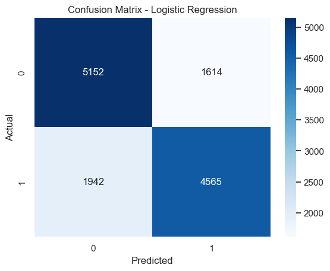

```python
from sklearn.metrics import confusion_matrix
import seaborn as sns
import matplotlib.pyplot as plt

cm = confusion_matrix(y_test, y_pred_log)

sns.heatmap(cm, annot=True, fmt="d", cmap="Blues")
plt.xlabel("Predicted")
plt.ylabel("Actual")
plt.title("Confusion Matrix - Logistic Regression")
plt.show()
```

## **12. ROC Curve**

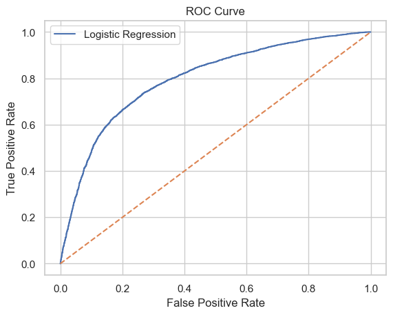

```python
from sklearn.metrics import roc_curve

fpr, tpr, _ = roc_curve(y_test, y_prob_log)

plt.plot(fpr, tpr, label="Logistic Regression")
plt.plot([0,1], [0,1], linestyle="--")
plt.xlabel("False Positive Rate")
plt.ylabel("True Positive Rate")
plt.title("ROC Curve")
plt.legend()
plt.show()
```

- At approximately 10% false positive rate, the model identifies about 45–50% of true disease cases.
- At approximately 20% false positive rate, the model identifies about 65% of disease cases.
- At approximately 40% false positive rate, the model identifies about 83% of disease cases.

The ROC curve demonstrates that the Logistic Regression model achieved good discriminative performance in distinguishing patients with and without cardiovascular disease. The curve lies substantially above the diagonal reference line representing random classification, indicating meaningful predictive capability. The model achieved an AUC-ROC of 0.797, suggesting that it correctly ranks a randomly selected diseased patient above a non-diseased patient approximately 80% of the time. While the model exhibits strong classification performance, the ROC curve also indicates potential room for improvement through more flexible machine learning algorithms such as Random Forests or Support Vector Machines, which may better capture complex nonlinear relationships among cardiovascular risk factors.

## **13. Feature Importance**

```python
# Extract coefficients
coeffs = pd.DataFrame({
    "Feature": feature_names,
    "Coefficient": best_model.coef_[0]
})

# Sort by importance
coeffs["abs_coeff"] = coeffs["Coefficient"].abs()
coeffs_sorted = coeffs.sort_values(by="abs_coeff", ascending=False)

print(coeffs_sorted.head(20))
```

```
                  Feature  Coefficient  abs_coeff
2                   ap_hi     0.952793   0.952793
9               age_years     0.324105   0.324105
39        ap_hi age_years    -0.189067   0.189067
4             cholesterol     0.178163   0.178163
34      ap_hi cholesterol    -0.166766   0.166766
10                    BMI     0.165083   0.165083
49          cholesterol^2     0.136312   0.136312
3                   ap_lo     0.125786   0.125786
38           ap_hi active     0.084101   0.084101
40              ap_hi BMI    -0.071677   0.071677
5                    gluc     0.071415   0.071415
54  cholesterol age_years    -0.065746   0.065746
74            age_years^2     0.064163   0.064163
41                ap_lo^2     0.063886   0.063886
50       cholesterol gluc    -0.059884   0.059884
36            ap_hi smoke     0.049957   0.049957
47        ap_lo age_years    -0.044144   0.044144
8                  active    -0.043339   0.043339
45             ap_lo alco     0.042714   0.042714
42      ap_lo cholesterol    -0.038915   0.038915
```

**Observations**

1. Higher systolic blood pressure (Coefficient = 0.953) substantially increases cardiovascular disease risk.
2. Cardiovascular disease risk increases with age (Coefficient = 0.324).
3. High blood pressure and age (Coefficient = -0.189): Interaction terms are harder to interpret directly because they depend on both variables simultaneously.
4. Elevated cholesterol (Coefficient = 0.178) is associated with increased cardiovascular disease risk.
5. Increasing BMI (Coefficient = 0.165) contributes positively to cardiovascular disease risk.
6. cholesterol^2: The relationship between cholesterol and cardiovascular disease is not perfectly linear. Risk may increase more rapidly at higher cholesterol levels.
7. age^2: Cardiovascular risk accelerates with increasing age rather than increasing at a constant rate.

**Explanation**

Examination of the Logistic Regression coefficients revealed that systolic blood pressure (ap_hi) was the strongest predictor of cardiovascular disease, followed by age, cholesterol level, BMI and diastolic blood pressure. Several interaction terms, particularly those involving blood pressure, age and cholesterol, were also among the most influential predictors, suggesting complex relationships between these risk factors. The presence of significant quadratic terms (e.g., cholesterol² and age²) indicates that cardiovascular risk does not increase linearly across all predictor values. Overall, the findings are consistent with established cardiovascular disease literature, which identifies hypertension, ageing, obesity and dyslipidaemia as major contributors to disease risk.

# **C. Decision Tree**

Decision Tree will complement Logistic Regression by providing:

- non-linear modeling
- automatic interaction handling
- high interpretability (rule-based)

## **1. Use SAME Clean Dataset**

```python
X = df_clean.drop(columns=["cardio"])
y = df_clean["cardio"]
```

## **2. Handle Multicollinearity**

- Remove weight again (since BMI already included)
- Decision Trees are less sensitive to multicollinearity
- But removing redundant features improves clarity

```python
X = X.drop(columns=["weight"])
```

## **3. Train/Test Split**

```python
from sklearn.model_selection import train_test_split

X_train, X_test, y_train, y_test = train_test_split(
    X, y, test_size=0.2, random_state=42, stratify=y
)
```

## **4. No Scaling Required**

## **5. Baseline Decision Tree**

```python
from sklearn.tree import DecisionTreeClassifier

# Basic model (no tuning yet)
dt = DecisionTreeClassifier(random_state=42)

dt.fit(X_train, y_train)
```

```
DecisionTreeClassifier(random_state=42)
```

## **6. Evaluate Baseline Model**

```python
from sklearn.metrics import accuracy_score, precision_score, recall_score, f1_score, roc_auc_score

y_pred = dt.predict(X_test)
y_prob = dt.predict_proba(X_test)[:, 1]

print("Baseline Decision Tree Performance:")
print("Accuracy:", accuracy_score(y_test, y_pred))
print("Precision:", precision_score(y_test, y_pred))
print("Recall:", recall_score(y_test, y_pred))
print("F1-score:", f1_score(y_test, y_pred))
print("AUC-ROC:", roc_auc_score(y_test, y_prob))
```

```
Baseline Decision Tree Performance:
Accuracy: 0.6333157537858811
Precision: 0.6280849734457982
Recall: 0.6179499001075764
F1-score: 0.6229762181423812
AUC-ROC: 0.6332074860057708
```

## **7. Hyperparameter Tuning (GridSearchCV)**

Control:

- tree depth
- minimum samples
- splitting criteria

```python
from sklearn.model_selection import GridSearchCV

param_grid = {
    "max_depth": [3, 5, 10, None],
    "min_samples_split": [2, 5, 10],
    "min_samples_leaf": [1, 5, 10],
    "criterion": ["gini", "entropy"]
}

grid_dt = GridSearchCV(
    DecisionTreeClassifier(random_state=42),
    param_grid,
    cv=10,
    scoring="roc_auc",
    n_jobs=-1
)

grid_dt.fit(X_train, y_train)

print("Best parameters:", grid_dt.best_params_)
```

```
Best parameters: {'criterion': 'gini', 'max_depth': 5, 'min_samples_leaf': 10, 'min_samples_split': 2}
```

Hyperparameter optimisation using 10-fold cross-validation identified a Decision Tree with Gini impurity, a maximum depth of five levels, a minimum leaf size of ten observations, and a minimum split size of two observations as the optimal configuration. The preference for a relatively shallow tree suggests that simpler decision rules provided better generalisation performance than more complex tree structures. Requiring at least ten observations in each terminal node further reduced the likelihood of overfitting by preventing highly specific splits based on small subsets of patients. Overall, the selected hyperparameters indicate that cardiovascular disease risk in this dataset can be effectively characterised using a limited number of clinically meaningful predictors while maintaining robust predictive performance.

## **8. Train Best Model**

```python
best_dt = grid_dt.best_estimator_

best_dt.fit(X_train, y_train)
```

```
DecisionTreeClassifier(max_depth=5, min_samples_leaf=10, random_state=42)
```

## **9. Final Evaluation**

```python
y_pred_dt = best_dt.predict(X_test)
y_prob_dt = best_dt.predict_proba(X_test)[:, 1]

dt_acc = accuracy_score(y_test, y_pred_dt)
dt_prec = precision_score(y_test, y_pred_dt)
dt_rec = recall_score(y_test, y_pred_dt)
dt_f1 = f1_score(y_test, y_pred_dt)
dt_auc = roc_auc_score(y_test, y_prob_dt)

print("Tuned Decision Tree Performance:")
print("Accuracy:", accuracy_score(y_test, y_pred_dt))
print("Precision:", precision_score(y_test, y_pred_dt))
print("Recall:", recall_score(y_test, y_pred_dt))
print("F1-score:", f1_score(y_test, y_pred_dt))
print("AUC-ROC:", roc_auc_score(y_test, y_prob_dt))
```

```
Tuned Decision Tree Performance:
Accuracy: 0.7294507647103142
Precision: 0.7516396272005523
Recall: 0.669279237743968
F1-score: 0.7080725144297212
AUC-ROC: 0.7911712305459171
```

The optimized Logistic Regression model slightly outperformed the tuned Decision Tree across most evaluation metrics. Logistic Regression achieved higher accuracy (73.2% vs. 72.9%), recall (70.2% vs. 66.9%), F1-score (0.720 vs. 0.708) and AUC-ROC (0.797 vs. 0.791), indicating superior overall predictive performance and discrimination ability. In contrast, the Decision Tree achieved marginally higher precision (75.2% vs. 73.9%), suggesting a lower false-positive rate. The relatively small performance difference between the models suggests that the relationships between cardiovascular disease and the predictor variables are largely captured by simple decision boundaries. Given its superior discrimination performance and greater interpretability, Logistic Regression appears to be the more suitable model for predicting cardiovascular disease in this dataset.

## **10. Confusion Matrix**

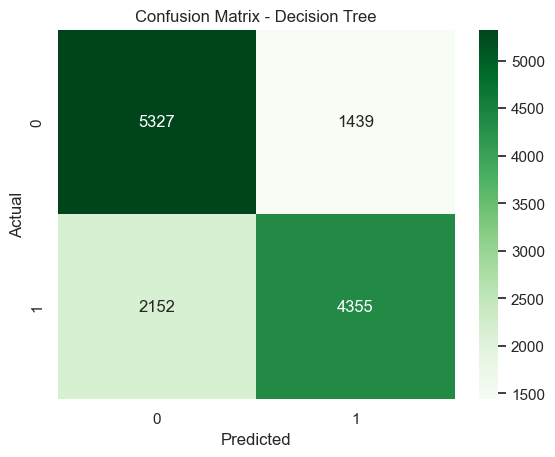

```python
from sklearn.metrics import confusion_matrix
import seaborn as sns
import matplotlib.pyplot as plt

cm = confusion_matrix(y_test, y_pred_dt)

sns.heatmap(cm, annot=True, fmt="d", cmap="Greens")
plt.xlabel("Predicted")
plt.ylabel("Actual")
plt.title("Confusion Matrix - Decision Tree")
plt.show()
```

## **11. ROC Curve**

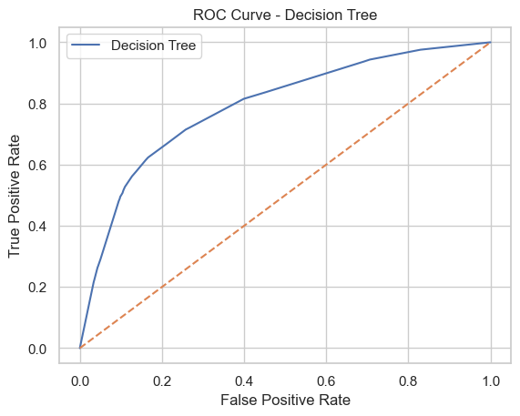

```python
from sklearn.metrics import roc_curve

fpr, tpr, _ = roc_curve(y_test, y_prob_dt)

plt.plot(fpr, tpr, label="Decision Tree")
plt.plot([0,1], [0,1], linestyle="--")
plt.xlabel("False Positive Rate")
plt.ylabel("True Positive Rate")
plt.title("ROC Curve - Decision Tree")
plt.legend()
plt.show()
```

The ROC curve of the tuned Decision Tree classifier demonstrates good discriminative performance, with an AUC-ROC of 0.791. The curve remains substantially above the diagonal reference line, indicating that the model effectively distinguishes between patients with and without cardiovascular disease. The steep rise in sensitivity at relatively low false-positive rates suggests that the model can identify a substantial proportion of disease cases while maintaining acceptable specificity. Although the Decision Tree achieved competitive performance, its AUC was slightly lower than that of the Logistic Regression model (0.791 vs. 0.797), indicating marginally weaker overall discrimination. These findings suggest that while nonlinear decision rules contribute useful predictive information, the underlying relationships in the dataset can be captured effectively by a simpler regularized Logistic Regression model.

## **12. Feature Importance**

```python
import pandas as pd

importance = pd.DataFrame({
    "Feature": X.columns,
    "Importance": best_dt.feature_importances_
}).sort_values(by="Importance", ascending=False)

print(importance)
```

```
        Feature  Importance
2         ap_hi    0.778883
9     age_years    0.125751
4   cholesterol    0.075069
10          BMI    0.006494
5          gluc    0.005716
3         ap_lo    0.004810
8        active    0.001679
1        height    0.000818
6         smoke    0.000779
0        gender    0.000000
7          alco    0.000000
```

Feature importance analysis of the optimized Decision Tree revealed that systolic blood pressure (ap_hi) was by far the most influential predictor, accounting for approximately 77.9% of the total model importance. Age (age_years) and cholesterol level were the next most important variables, contributing 12.6% and 7.5%, respectively. Together, these three predictors accounted for approximately 98% of the model's predictive capability. In contrast, variables such as BMI, glucose level, physical activity, smoking status and height contributed minimally to model performance, while gender and alcohol consumption were not used in any tree split. These findings are broadly consistent with the Logistic Regression results and reinforce the central role of hypertension, ageing and dyslipidaemia in predicting cardiovascular disease risk.

## **13. Visualize Tree**

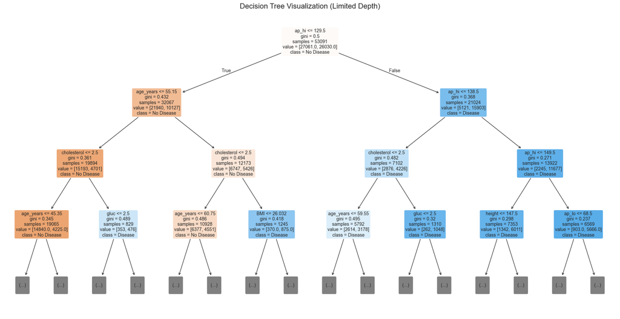

```python
from sklearn.tree import plot_tree
import matplotlib.pyplot as plt

# ✅ IMPORTANT: Limit depth for readability (publication quality)
max_display_depth = 3   # You can try 3–5 depending on clarity

plt.figure(figsize=(24, 12))  # Large figure for clarity

plot_tree(
    best_dt,
    feature_names=X.columns,
    class_names=["No Disease", "Disease"],
    filled=True,
    rounded=True,
    fontsize=10,
    max_depth=max_display_depth   # ✅ controls complexity of displayed tree
)

plt.title("Decision Tree Visualization (Limited Depth)", fontsize=16)

# ✅ Save high-quality image
plt.savefig("decision_tree_high_quality.png", dpi=600, bbox_inches="tight")

# ✅ Optional: Save as vector (BEST for reports)
plt.savefig("decision_tree_high_quality.pdf", bbox_inches="tight")

plt.show()
```

```python
!pip install graphviz
```

```
Downloading graphviz-0.21-py3-none-any.whl (47 kB)
```

```python
# save a better version for report.
from sklearn.tree import export_graphviz
import graphviz

dot_data = export_graphviz(
    best_dt,
    out_file=None,
    feature_names=X.columns,
    class_names=["No Disease", "Disease"],
    filled=True,
    rounded=True,
    max_depth=3
)

graph = graphviz.Source(dot_data)

# Save
graph.render("decision_tree_graphviz", format="png", cleanup=True)
# plot saved.
```

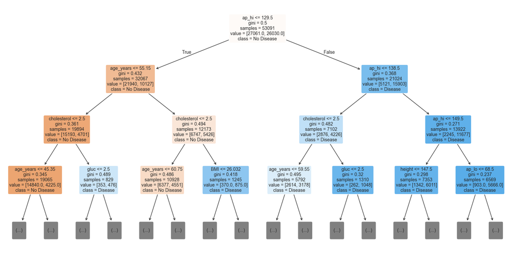

```python
from sklearn.tree import plot_tree
import matplotlib.pyplot as plt

# Create a larger figure for better readability
plt.figure(figsize=(20, 10))

# Plot the decision tree
plot_tree(
    best_dt,
    feature_names=X.columns,
    class_names=["No Disease", "Disease"],
    filled=True,
    rounded=True,
    max_depth=3,
    fontsize=10
)

# Save the plot
plt.savefig("decision_tree_matplotlib.png", dpi=300, bbox_inches='tight')
plt.show()
```

# **D. Random Forest**

Random Forest:

- Reduces overfitting (compared to Decision Tree)
- Captures non-linear relationships
- Handles interactions automatically
- Less interpretable than Logistic / Tree

## **1. Prepare Data (Same as Before)**

```python
# Features and target
X = df_clean.drop(columns=["cardio"])
y = df_clean["cardio"]

# Remove highly correlated variable (same as before)
X = X.drop(columns=["weight"])
```

## **2. Train/Test Split**

```python
from sklearn.model_selection import train_test_split

X_train, X_test, y_train, y_test = train_test_split(
    X, y, test_size=0.2, random_state=42, stratify=y
)
```

## **3. No Scaling Needed**

Random Forest is tree-based → no scaling required

## **4. Baseline Random Forest**

```python
from sklearn.ensemble import RandomForestClassifier

rf = RandomForestClassifier(random_state=42)

rf.fit(X_train, y_train)
```

```
RandomForestClassifier(random_state=42)
```

## **5. Evaluate Baseline Model**

```python
from sklearn.metrics import accuracy_score, precision_score, recall_score, f1_score, roc_auc_score

y_pred_rf = rf.predict(X_test)
y_prob_rf = rf.predict_proba(X_test)[:, 1]

print("Baseline Random Forest Performance:")
print("Accuracy:", accuracy_score(y_test, y_pred_rf))
print("Precision:", precision_score(y_test, y_pred_rf))
print("Recall:", recall_score(y_test, y_pred_rf))
print("F1-score:", f1_score(y_test, y_pred_rf))
print("AUC-ROC:", roc_auc_score(y_test, y_prob_rf))
```

```
Baseline Random Forest Performance:
Accuracy: 0.7089580351088677
Precision: 0.7087148721187243
Recall: 0.689872445059167
F1-score: 0.6991667315629624
AUC-ROC: 0.7688501039445412
```

## **6. Hyperparameter Tuning**

We tune:

- number of trees (n_estimators)
- tree depth (max_depth)
- split rules

```python
from sklearn.model_selection import GridSearchCV

param_grid = {
    "n_estimators": [100, 200],
    "max_depth": [5, 10, None],
    "min_samples_split": [2, 5], # Minimum observations needed before a node can split.
                                # Higher values reduce overfitting.
    "min_samples_leaf": [1, 5], # Minimum observations allowed in terminal nodes.
                                # Larger values produce smoother predictions.
    "max_features": ["sqrt", "log2"] # Number of candidate predictors considered at each split.
                                    # This introduces randomness and reduces correlation among trees.
}

grid_rf = GridSearchCV(
    RandomForestClassifier(random_state=42),
    param_grid,
    cv=10,
    scoring="roc_auc",
    n_jobs=-1
)

grid_rf.fit(X_train, y_train)

print("Best parameters:", grid_rf.best_params_)
```

```
Best parameters: {'max_depth': 10, 'max_features': 'sqrt', 'min_samples_leaf': 5, 'min_samples_split': 2, 'n_estimators': 200}
```

Grid search identified a Random Forest with 200 trees, maximum tree depth of 10, square-root feature sampling, and a minimum leaf size of five as the optimal configuration. This indicates that moderate tree complexity and ensemble averaging improved predictive stability while limiting overfitting.

## **7. Final Model**

```python
best_rf = grid_rf.best_estimator_

best_rf.fit(X_train, y_train)
```

```
RandomForestClassifier(max_depth=10, min_samples_leaf=5, n_estimators=200,
                       random_state=42)
```

## **8. Final Evaluation**

```python
y_pred_rf = best_rf.predict(X_test)
y_prob_rf = best_rf.predict_proba(X_test)[:, 1]


rf_acc = accuracy_score(y_test, y_pred_rf)
rf_prec = precision_score(y_test, y_pred_rf)
rf_rec = recall_score(y_test, y_pred_rf)
rf_f1 = f1_score(y_test, y_pred_rf)
rf_auc = roc_auc_score(y_test, y_prob_rf)


print("Random Forest Performance:")
print(rf_acc, rf_prec, rf_rec, rf_f1, rf_auc)
```

```
Random Forest Performance:
0.7338958788518044 0.7569528415961306 0.673428615337329 0.7127521145087834 0.799346355258697
```

## **9. Confusion Matrix**

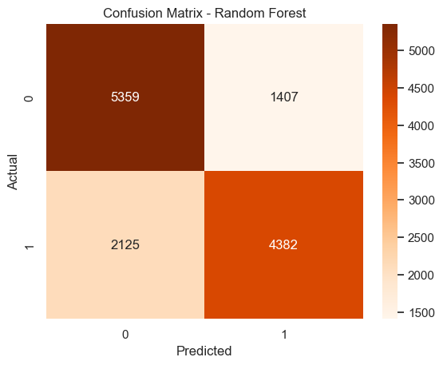

```python
from sklearn.metrics import confusion_matrix
import seaborn as sns
import matplotlib.pyplot as plt

cm = confusion_matrix(y_test, y_pred_rf)

sns.heatmap(cm, annot=True, fmt="d", cmap="Oranges")
plt.xlabel("Predicted")
plt.ylabel("Actual")
plt.title("Confusion Matrix - Random Forest")
plt.show()
```

## **10. ROC Curve**

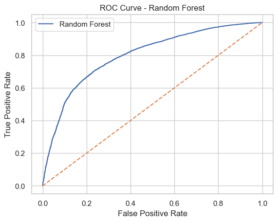

```python
from sklearn.metrics import roc_curve

fpr, tpr, _ = roc_curve(y_test, y_prob_rf)

plt.plot(fpr, tpr, label="Random Forest")
plt.plot([0,1], [0,1], linestyle="--")
plt.xlabel("False Positive Rate")
plt.ylabel("True Positive Rate")
plt.title("ROC Curve - Random Forest")
plt.legend()
plt.show()
```

## **11. Feature Importance**

```python
import pandas as pd

importance = pd.DataFrame({
    "Feature": X.columns,
    "Importance": best_rf.feature_importances_
}).sort_values(by="Importance", ascending=False)

print(importance)
```

```
        Feature  Importance
2         ap_hi    0.477470
3         ap_lo    0.177066
9     age_years    0.137102
4   cholesterol    0.088829
10          BMI    0.063938
1        height    0.024214
5          gluc    0.011395
8        active    0.008317
0        gender    0.004496
6         smoke    0.004059
7          alco    0.003115
```

Feature importance analysis of the tuned Random Forest model revealed that systolic blood pressure (ap_hi) was the most influential predictor, accounting for approximately 47.7% of the total importance. Diastolic blood pressure (ap_lo) emerged as the second most important variable (17.7%), followed by age (13.7%), cholesterol level (8.8%) and BMI (6.4%). Together, these five variables contributed more than 94% of the model's predictive capability. Lifestyle-related variables such as smoking, alcohol consumption and physical activity exhibited relatively low importance scores.

## **12. Plot Feature Importance**

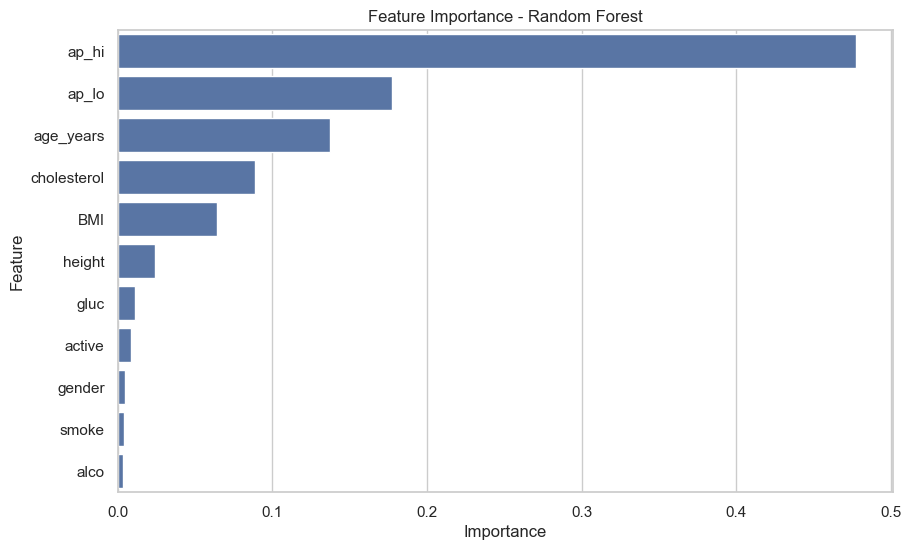

```python
plt.figure(figsize=(10, 6))

sns.barplot(
    x="Importance",
    y="Feature",
    data=importance
)

plt.title("Feature Importance - Random Forest")
plt.show()
```

# **E. Support Vector Machine (SVM)**

- Strong for complex nonlinear relationships
- Works well in high-dimensional space
- Handles interactions implicitly via kernels
- Low interpretability
- Requires scaling

## **1. Prepare Data (Same as Previous Models)**

```python
# Features and target
X = df_clean.drop(columns=["cardio"])
y = df_clean["cardio"]

# Remove highly correlated variable (same logic)
X = X.drop(columns=["weight"])
```

## **2. Train/Test Split**

```python
from sklearn.model_selection import train_test_split

X_train, X_test, y_train, y_test = train_test_split(
    X, y, test_size=0.2, random_state=42, stratify=y
)
```

## **3. Feature Scaling**

```python
from sklearn.preprocessing import StandardScaler

scaler = StandardScaler()

X_train_scaled = scaler.fit_transform(X_train)
X_test_scaled = scaler.transform(X_test)
```

## **4. Baseline SVM Model**

```python
from sklearn.svm import SVC

# RBF kernel captures nonlinear relationships
svm_model = SVC(kernel='rbf', probability=True, random_state=42)

svm_model.fit(X_train_scaled, y_train)
```

```
SVC(probability=True, random_state=42)
```

## **5. Evaluate Baseline Model**

```python
from sklearn.metrics import accuracy_score, precision_score, recall_score, f1_score, roc_auc_score

y_pred = svm_model.predict(X_test_scaled)
y_prob = svm_model.predict_proba(X_test_scaled)[:, 1]

print("Baseline SVM Performance:")
print("Accuracy:", accuracy_score(y_test, y_pred))
print("Precision:", precision_score(y_test, y_pred))
print("Recall:", recall_score(y_test, y_pred))
print("F1-score:", f1_score(y_test, y_pred))
print("AUC-ROC:", roc_auc_score(y_test, y_prob))
```

```
Baseline SVM Performance:
Accuracy: 0.7322383786634521
Precision: 0.7609118218766566
Recall: 0.6617488858152759
F1-score: 0.7078744040769357
AUC-ROC: 0.7886435517883581
```

## **6. Hyperparameter Tuning**

We tune:

- C → regularisation strength
- gamma → kernel influence

```python
from sklearn.model_selection import RandomizedSearchCV

param_dist = {
    "C": [0.1, 1, 10],
    "gamma": ["scale", 0.1, 0.01],
    "kernel": ["rbf"]
}

# RandomizedSearchCV used to run the model faster, otherwise, GridSearchCV was
# taking ages to finish.
grid_svm = RandomizedSearchCV(
    SVC(probability=True, random_state=42),
    param_distributions=param_dist,
    n_iter=5,
    cv=10,
    scoring="roc_auc",
    n_jobs=-1,
    random_state=42
)

grid_svm.fit(X_train_scaled, y_train)

print("Best parameters:", grid_svm.best_params_)
```

```
Best parameters: {'kernel': 'rbf', 'gamma': 0.01, 'C': 1}
```

## **7. Train Best Model**

```python
best_svm = grid_svm.best_estimator_

best_svm.fit(X_train_scaled, y_train)
```

```
SVC(C=1, gamma=0.01, probability=True, random_state=42)
```

## **8. Final Evaluation**

```python
y_pred_svm = best_svm.predict(X_test_scaled)
y_prob_svm = best_svm.predict_proba(X_test_scaled)[:, 1]

svm_acc = accuracy_score(y_test, y_pred_svm)
svm_prec = precision_score(y_test, y_pred_svm)
svm_rec = recall_score(y_test, y_pred_svm)
svm_f1 = f1_score(y_test, y_pred_svm)
svm_auc = roc_auc_score(y_test, y_prob_svm)

print("Tuned SVM Performance:")
print("Accuracy:", accuracy_score(y_test, y_pred_svm))
print("Precision:", precision_score(y_test, y_pred_svm))
print("Recall:", recall_score(y_test, y_pred_svm))
print("F1-score:", f1_score(y_test, y_pred_svm))
print("AUC-ROC:", roc_auc_score(y_test, y_prob_svm))
```

```
Tuned SVM Performance:
Accuracy: 0.7302795148044903
Precision: 0.7562598494134127
Recall: 0.6637467342861534
F1-score: 0.7069896873465379
AUC-ROC: 0.7914033755503123
```

## **9. Confusion Matrix**

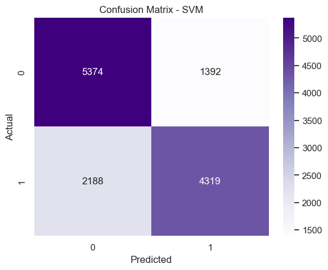

```python
from sklearn.metrics import confusion_matrix
import seaborn as sns
import matplotlib.pyplot as plt

cm = confusion_matrix(y_test, y_pred_svm)

sns.heatmap(cm, annot=True, fmt="d", cmap="Purples")
plt.xlabel("Predicted")
plt.ylabel("Actual")
plt.title("Confusion Matrix - SVM")
plt.show()
```

## **10. ROC Curve**

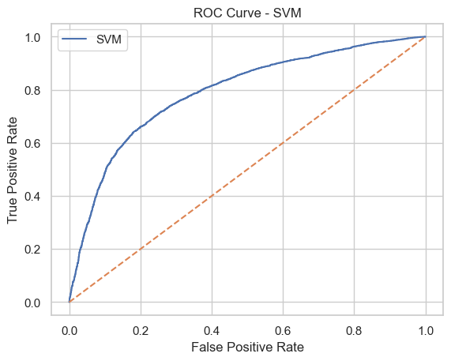

```python
from sklearn.metrics import roc_curve

fpr, tpr, _ = roc_curve(y_test, y_prob_svm)

plt.plot(fpr, tpr, label="SVM")
plt.plot([0,1], [0,1], linestyle="--")
plt.xlabel("False Positive Rate")
plt.ylabel("True Positive Rate")
plt.title("ROC Curve - SVM")
plt.legend()
plt.show()
```

## **Model Comparison Table**

```python
results = pd.DataFrame({
    "Model": ["Logistic Regression", "Decision Tree", "Random Forest", "SVM"],
    "Accuracy": [log_acc, dt_acc, rf_acc, svm_acc],
    "Precision": [log_prec, dt_prec, rf_prec, svm_prec],
    "Recall": [log_rec, dt_rec, rf_rec, svm_rec],
    "F1": [log_f1, dt_f1, rf_f1, svm_f1],
    "AUC": [log_auc, dt_auc, rf_auc, svm_auc]
})

print(results)
```

```
                 Model  Accuracy  Precision    Recall        F1       AUC
0  Logistic Regression  0.732088   0.738793  0.701552  0.719691  0.796866
1        Decision Tree  0.729451   0.751640  0.669279  0.708073  0.791171
2        Random Forest  0.733896   0.756953  0.673429  0.712752  0.799346
3                  SVM  0.730280   0.756260  0.663747  0.706990  0.791403
```

## **Key Observations**

**1. Random Forest is the Best Overall Model**

- Highest Accuracy (0.734)
- Highest Precision (0.757)
- Highest AUC (0.799)

This confirms:

Random Forest provides the best predictive performance.

**2. Logistic Regression is VERY Close to Random Forest**

- Metrics are nearly identical
- Especially:
  - Accuracy (~0.73)
  - AUC (~0.79)

**The dataset likely has mostly linear relationships, so complex models do not significantly outperform simpler ones.**

**3. Decision Tree Slightly Underperforms**

- Lower Recall and AUC
- Likely due to:
  - Overfitting even after tuning

**4. SVM Performs Well but Not the Best**

- Strong Precision
- Lower Recall
- Similar to Decision Tree overall

# **Model Ranking**

- **Best (Performance): Random Forest**
- **Close Second: Logistic Regression**
- Third: SVM
- Last: Decision Tree

Among the evaluated models, the Random Forest classifier achieved the best overall predictive performance, with the highest accuracy, precision, and AUC-ROC score. This demonstrates its ability to capture complex patterns and interactions in the dataset.

Although Random Forest performed best, Logistic Regression produced very similar results, indicating that the relationships in the dataset are largely linear. Logistic Regression also provides greater interpretability through its coefficients, making it valuable for understanding the impact of risk factors. In a healthcare context, where interpretability is crucial, Logistic Regression may be preferred if its performance is comparable. However, for purely predictive objectives, Random Forest is the most suitable model.

The minimal performance difference between Random Forest and Logistic Regression suggests that the dataset does not contain strong non-linear patterns. This indicates that simpler models may be sufficient for cardiovascular disease prediction in this dataset.

*This study compared Logistic Regression, Decision Tree, Random Forest, and Support Vector Machine models for predicting cardiovascular disease. Random Forest achieved the highest predictive performance, while Logistic Regression offered comparable results with greater interpretability. The findings highlight a trade-off between model complexity and explainability, with simpler models performing nearly as well as more complex ones due to the largely linear relationships in the dataset.*